# Support Vector Machines

Nik Bear Brown

# Additional packages needed

To run the code in M06_Lesson_03.Rmd you may need additional packages.

- If necessary install the followings packages.

`install.packages("ggplot2");`  
`install.packages("e1071");`  
`install.packages("kernlab");`

```r
require(ggplot2)
require(e1071)
require(kernlab)
```

# Data

```r
data_url <- 'http://nikbearbrown.com/YouTube/MachineLearning/M06/svm_regression.csv'
svm.data <- read.csv(url(data_url), sep=",", header = TRUE)
head(svm.data)
```

```
##   X Y
## 1 1 3
## 2 2 4
## 3 3 8
## 4 4 4
## 5 5 6
## 6 6 9
```

# Support Vector Machines

Support vector machine constructs a hyperplane or set of hyperplanes in a high- or infinite-dimensional space, which can be used for classification, regression, or other tasks. Given a set of data points that belong to either of two classes, an SVM finds the hyperplane that:

- Leaves the largest possible fraction of points of the same class on the same side.
- Maximizes the distance of either class from the hyperplane.
- Find the optimal separating hyperplane that minimizes the risk of misclassifying the training samples and unseen test samples.

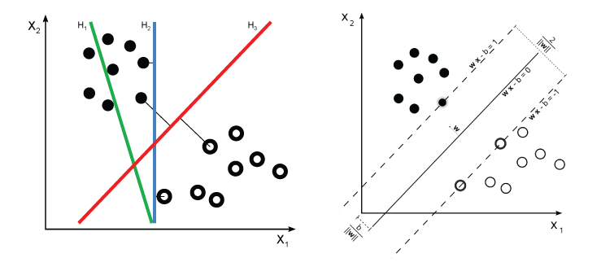

*SVM*

Pseudocode

Given a guess of width and bias we can:

- Compute whether all data points are in the correct half-planes.
- Compute the width of the margin.
- Search the space of widthâs and bias to find the widest margin that matches all the datapoints.

## Kernels

It is much easier and efficient to find Separating boundaries which are in the form of a straight lines as oppossed to curvy Separating boundaries. Kernels help us turn a linear classifier into a non-linear one. That is, they transform a curvy separating boundary that is only non-linearly separable to a linearly separable discriminant in a higher dimensional space.

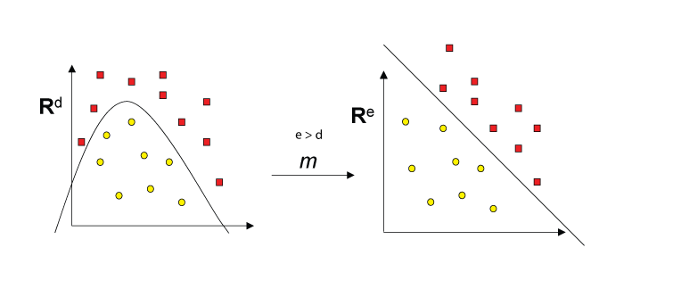

Kernels

### Kernels (1-D Example)

For example, squaring the data may take some points that are not linearly separable in 1-D space to be linearly separable in 2D space.

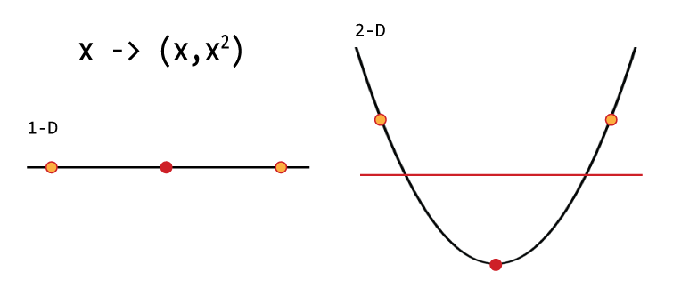

Kernels

## Kernel Trick

While coming up with functions that map linearly separable sets to SVM, we only need to know the inner product of vectors in the linearly separable sets in higher dimensional spaces arbitrarily coordinate space.

Computing the kernel of x and y gives the same result as the dot product in the mapped (high-dimensional) space. The mappings used by SVM schemes are designed to ensure that dot products may be computed easily in terms of the variables in the original space, by defining them in terms of a kernel function k(x,y) selected to suit the problem. This “Kernel trick” is" essentially is to define a similarity function in terms of original space itself without even defining (or even knowing), what the transformation function K will be.

## Linear SVM

Support Vectors are those datapoints that the margin pushes up against

Given some training data $\mathcal{D}$, a set of n points of the form $\mathcal{D} = \left\{ (\mathbf{x}_i, y_i)\mid\mathbf{x}_i \in \mathbb{R}^p,\, y_i \in \{-1,1\}\right\}_{i=1}^n$ where the $y_i$ is either 1 or â1, indicating the class to which the point $\mathbf{x}_i$ belongs. Each $\mathbf{x}_i$ is a p-dimensional real vector. We want to find the maximum-margin hyperplane that divides the points having $y_i=1$ from those having $y_i=-1$. Any hyperplane can be written as the set of points $\mathbf{x}$ satisfying $\mathbf{w}\cdot\mathbf{x} - b=0$, where $\mathbf{w}\cdot\mathbf{x}$,denotes the dot product of $\mathbf{w}$ and $\mathbf{x}$, The variable ${\mathbf{w}}$ is the (not necessarily normalized) normal vector to the hyperplane. The parameter $\tfrac{b}{\|\mathbf{w}\|}$ determines the offset of the hyperplane from the origin along the normal vector ${\mathbf{w}}$.

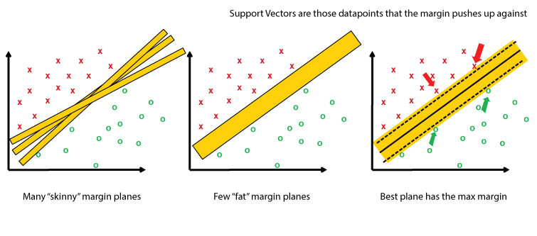

*Linear SVM*

# Non-Linear SVM

Non-linear classifiers are created by applying the kernel trick then generating maximum-margin hyperplanes.